# Quiz 1: Part 2

## Part 2: Coding in action

### Instructions

Please answer these questions in R using whatever syntax makes sense to you. Feel free to use the R help pages and/or notes from class.

**If you use Google or ChatGPT etc. to help you get to an answer, please note so on your answer**

Submit your answers as an html file. Name it “lastname_quiz1.html”. Two submission options:  
1. Email to mcnew@arizona.edu

2. Create a branch in your forked-and-cloned class repo. Add the html file to the student_contributions/ folder. Submit a pull request to Sabrina (extra credit).

```r
# load packages and data
library(dslabs)
library(dplyr)
library(readr)
```

#### Load your data:

Load the *swallows.csv* into R, call it swallows. This data frame lists results of an experiment on tree swallows. Each row is a nest. Nests were put into one of two **treatments**: simulated predation (predator), or control (control). Along with treatment you have the following columns:  
**nest_fate** = whether the nest fledged any young or whether they all died  
**brood** = number of nestlings  
**n_fledged** = number of nestlings that fledged.

You also have a separate data frame called *brightness.csv* where each row lists the plumage brightness (a sexual signal) for the female at each nest. Load this one up too.

```r
# Answer
#my file's path
swallows <- read_csv("C:/Users/Usuario/Downloads/Quiz1_ECOL596W/ECOL_596W_2024/quiz/swallows.csv")
brightness <- read_csv("C:/Users/Usuario/Downloads/Quiz1_ECOL596W/ECOL_596W_2024/quiz/brightness.csv")
# Google? y/n *no
```

#### Wrangle your data

You realize that you want to add brightness information onto your main swallows data frame. Join these data frames using nest_id as your key variable. Describe how you would check to make sure this join worked as intended.

```r
#Answer
swallows_mrg<-merge(swallows,brightness, by="nestbox")


View(swallows_mrg)
# Google? y/n *no
```

Inspect your combined data frame. Do some sort of quick sanity check on each column to catch any obvious entry errors. Correct as necessary

```r
# Answer
sum(is.na(swallows_mrg))
```

```
[1] 1
```

```r
complete.cases(swallows_mrg)
```

```
 [1]  TRUE  TRUE  TRUE  TRUE  TRUE  TRUE  TRUE  TRUE  TRUE  TRUE  TRUE FALSE
[13]  TRUE  TRUE  TRUE  TRUE  TRUE  TRUE  TRUE  TRUE  TRUE  TRUE  TRUE  TRUE
[25]  TRUE  TRUE  TRUE  TRUE  TRUE  TRUE  TRUE  TRUE  TRUE  TRUE  TRUE  TRUE
[37]  TRUE  TRUE  TRUE  TRUE  TRUE  TRUE
```

```r
unique(swallows_mrg$treatment)
```

```
[1] "Predation" "Control"
```

```r
unique(swallows_mrg$brood)
```

```
[1] 0 6 5 1 4 7 3 2
```

```r
unique(swallows_mrg$n_fledged)
```

```
[1] 0 1 2 4 5 6 3
```

```r
unique(swallows_mrg$brightness)
```

```
 [1] 35.3 50.6 33.9 42.4 53.6 56.0 55.9 57.0 56.2 62.6 55.8   NA 59.2 58.6 34.1
[16] 58.4 54.2 47.1 49.2 57.7 48.2 49.0 52.6 41.5 39.9 64.6 53.9 54.5 47.2 55.7
[31] 49.3 60.2 68.0 45.5 53.3 41.2 57.4 43.8 48.1
```

```r
#to ommit NA's
swallows_mrg_clean<-na.omit(swallows_mrg)

str(swallows_mrg)
```

```
'data.frame':   42 obs. of  5 variables:
 $ nestbox   : chr  "1_104" "1_12" "1_121" "1_123" ...
 $ treatment : chr  "Predation" "Control" "Predation" "Predation" ...
 $ brood     : num  0 6 6 5 5 1 5 4 5 5 ...
 $ n_fledged : num  0 1 2 0 0 0 4 2 4 4 ...
 $ brightness: num  35.3 50.6 33.9 42.4 53.6 56 55.9 57 56.2 62.6 ...
```

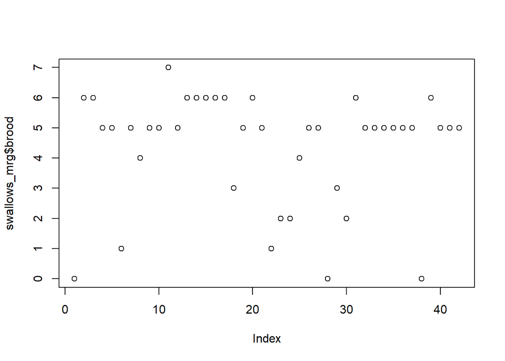

```r
plot(swallows_mrg$brood)
```

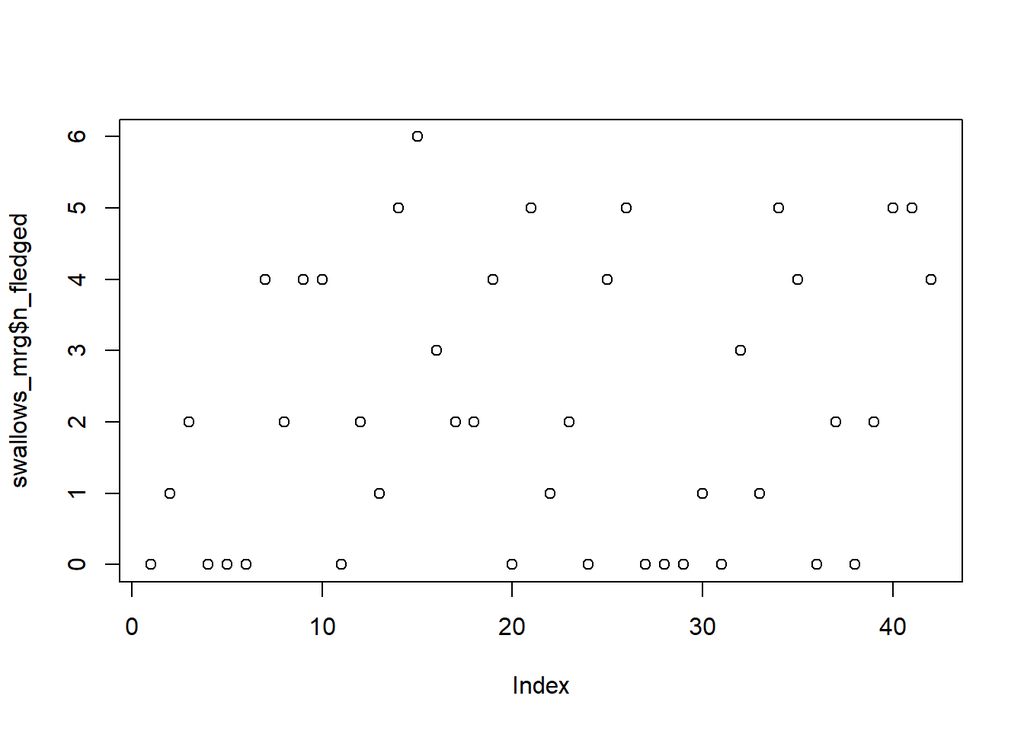

```r
plot(swallows_mrg$n_fledged)
```

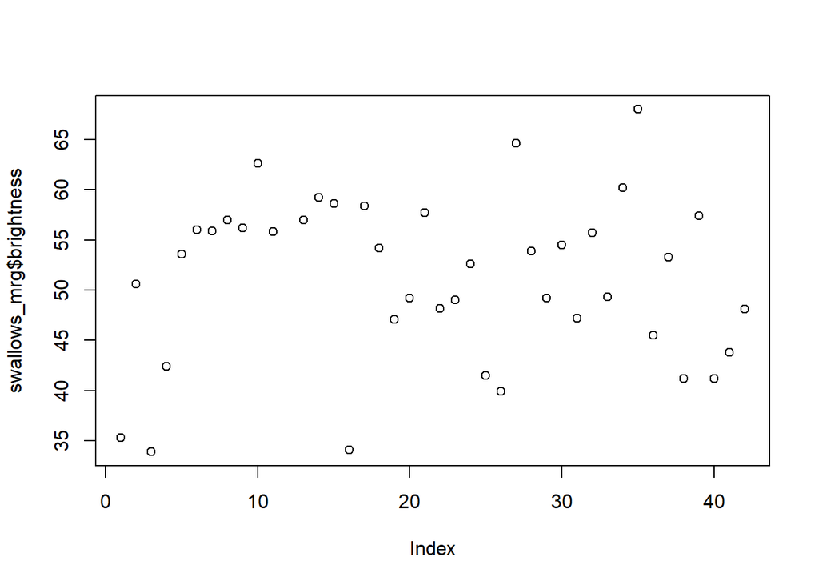

```r
plot(swallows_mrg$brightness)
```

```r
print(swallows_mrg_clean)
```

```
   nestbox treatment brood n_fledged brightness
1    1_104 Predation     0         0       35.3
2     1_12   Control     6         1       50.6
3    1_121 Predation     6         2       33.9
4    1_123 Predation     5         0       42.4
5     1_17 Predation     5         0       53.6
6     1_62 Predation     1         0       56.0
7     1_81   Control     5         4       55.9
8     1_85   Control     4         2       57.0
9     1_91 Predation     5         4       56.2
10   2_102   Control     5         4       62.6
11   2_105 Predation     7         0       55.8
13   2_114 Predation     6         1       57.0
14   2_117 Predation     6         5       59.2
15    2_12   Control     6         6       58.6
```

[output cut: 27 more lines]

```r
# Google y/n *no
```

Create a new column called prop_fledged that contains the proportion of nestlings that fledged from each nest.

```r
#Answer

#This was the first attempt
prop_fledged<-mutate(swallows_mrg_clean,(n_fledged*100)/brood)

swallows_mrg_clean$prop_fledged<-mutate(swallows_mrg_clean,(n_fledged*100)/brood)

#double checked w/ google
swallows_mrg_clean$prop_fledged<-((swallows_mrg_clean$n_fledged*100)/swallows_mrg_clean$brood)

print(swallows_mrg_clean)
```

```
   nestbox treatment brood n_fledged brightness prop_fledged
1    1_104 Predation     0         0       35.3          NaN
2     1_12   Control     6         1       50.6     16.66667
3    1_121 Predation     6         2       33.9     33.33333
4    1_123 Predation     5         0       42.4      0.00000
5     1_17 Predation     5         0       53.6      0.00000
6     1_62 Predation     1         0       56.0      0.00000
7     1_81   Control     5         4       55.9     80.00000
8     1_85   Control     4         2       57.0     50.00000
9     1_91 Predation     5         4       56.2     80.00000
10   2_102   Control     5         4       62.6     80.00000
11   2_105 Predation     7         0       55.8      0.00000
13   2_114 Predation     6         1       57.0     16.66667
14   2_117 Predation     6         5       59.2     83.33333
15    2_12   Control     6         6       58.6    100.00000
```

[output cut: 27 more lines]

```r
# Google? y/n *yes
```

#### Explore the data

What was the mean proportion of nestlings fledged in each treatment?

```r
# Answer

mean(swallows_mrg_clean$treatment=="Predation")
```

```
[1] 0.5121951
```

```r
mean(swallows_mrg_clean$treatment=="Control")
```

```
[1] 0.4878049
```

```r
# Google? y/n *no
```

Create a plot showing fledging success differences between treatments

```r
#Answer

#first I cleaned the NA's
swallows_mrg_clean2<-na.omit(swallows_mrg_clean)
unique(swallows_mrg_clean2$prop_fledged)
```

```
 [1]  16.66667  33.33333   0.00000  80.00000  50.00000  83.33333 100.00000
 [8]  66.66667  60.00000  20.00000  40.00000
```

```r
unique(swallows_mrg_clean2$treatment) #double checked
```

```
[1] "Control"   "Predation"
```

```r
swallows_mrg_clean2$treatment <- as.factor(swallows_mrg_clean2$treatment)
swallows_mrg_clean2$prop_fledged <- as.numeric(swallows_mrg_clean2$prop_fledged)


?boxplot
```

```
starting httpd help server ... done
```

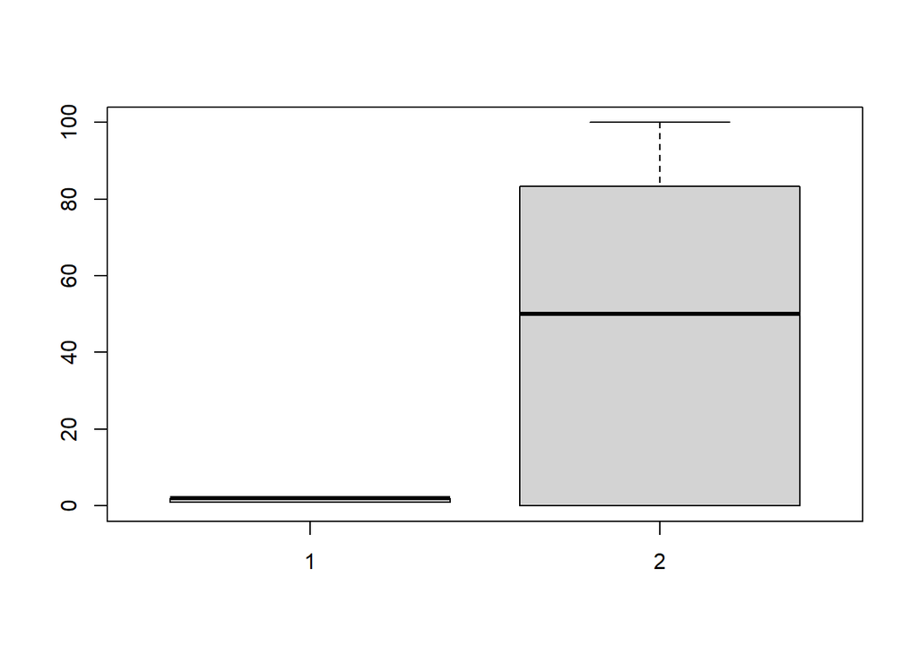

```r
#first look
boxplot(swallows_mrg_clean2$treatment,swallows_mrg_clean2$prop_fledged)
```

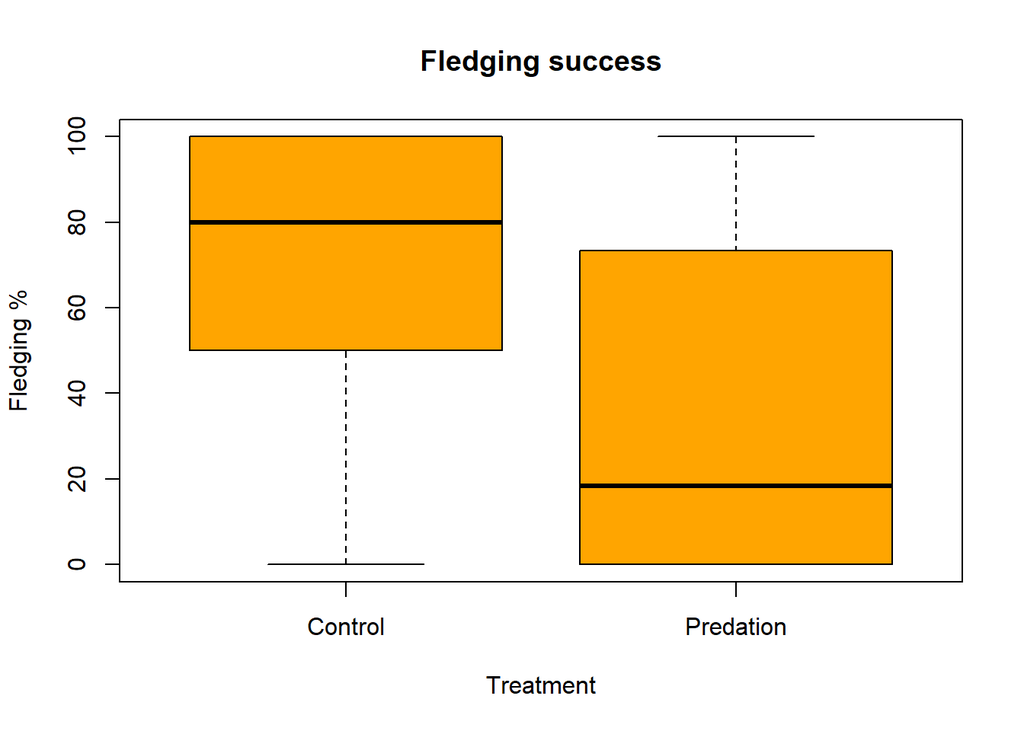

```r
#my attempt
plot(swallows_mrg_clean2$treatment,swallows_mrg_clean2$prop_fledged,
     main = "Fledging success",
     xlab = "Treatment",
     ylab = "Fledging %",
     col="orange")
```

```r
#I I had a mistake and I corrected it with google
boxplot(swallows_mrg_clean2$prop_fledged ~ swallows_mrg_clean2$treatment,
        main = "Fledging success",
        xlab = "Treatment",
        ylab = "Fledging %",
        col = "orange")

# Google? y/n *yes
```

[output not shown]

Is there any evidence that female brightness influenced fledging success? Create a plot to visually investigate this question.

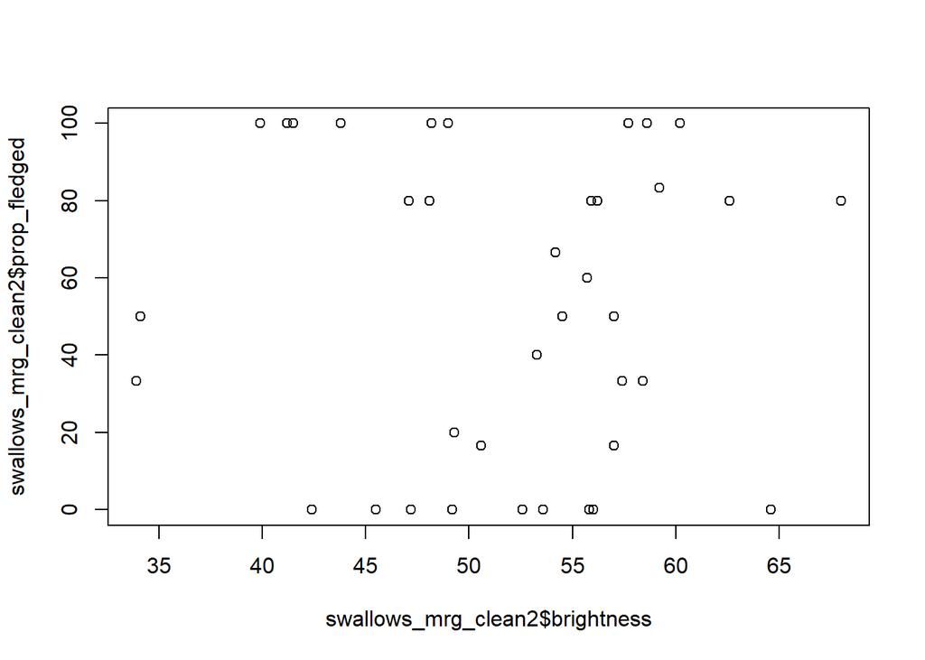

```r
#Answer

#first look
plot(swallows_mrg_clean2$brightness,swallows_mrg_clean2$prop_fledged)

#my attempt
library(ggplot2)
```

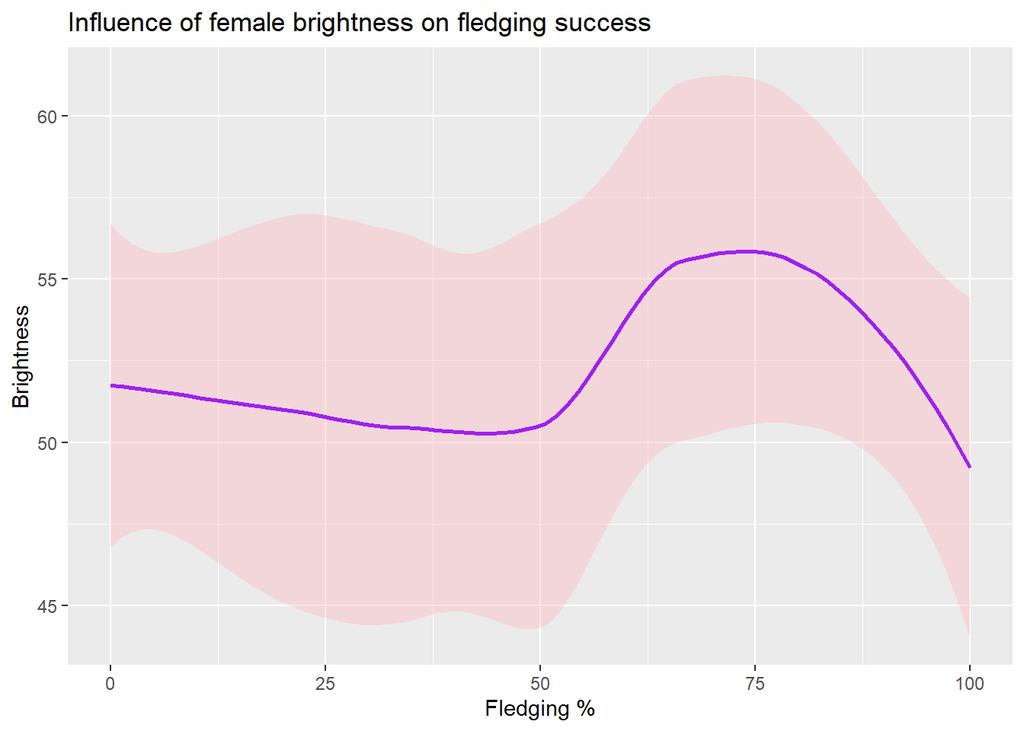

```r
swallows_mrg_clean2 |> ggplot(aes(x=prop_fledged, y=brightness))+
  geom_smooth(
    color="purple", fill="lightpink") +
  labs(title = "Influence of female brightness on fledging success",
       x= "Fledging %",
       y="Brightness")
```

```r
# Google? y/n **here I used google to ask how to change the "fill" color
```